# Python 进阶 (lecture for Solar Group)

## SunPy 示例

### 示例文件

- 读取 fits, submap, 作图 [example_plothmi](https://lydiazly.github.io/example_plothmi.html)
- 投影 [example_projection](https://lydiazly.github.io/example_projection.html)
- 下载数据 [fido](https://lydiazly.github.io/fido.html), [jsoc](https://lydiazly.github.io/jsoc.html)

  注意: 这些例子只是提供一个使用参考, 不一定是最优的.

### 示例中的 fits 读取方法

更多 FITS 的读取方法参见 Python 简易教程#FITS-文件读取  
另见 [Astropy 的命令行工具](http://docs.astropy.org/en/stable/io/fits/usage/scripts.html)

读取`HMIMap` 的例子:

```python
# 导入 `sunpy.map` 的时间会略有点长
import sunpy.map
smap = sunpy.map.Map('data/hmi.B_720s.20150827_052400_TAI.field.fits')
type(smap)
```

```
sunpy.map.sources.sdo.HMIMap
```

这是 `GenericMap` 的一个子类:

```python
issubclass(sunpy.map.sources.sdo.HMIMap, sunpy.map.mapbase.GenericMap)
True
```

```
True
```

```python
smap.meta  # headers
```

```python
type(smap.data)  # 索引从 0 开始
```

```
numpy.ndarray
```

```python
smap.data.shape  # (dimy, dimx)
```

```
(4096, 4096)
```

`smap.data[i, j]` 中的 i 为 Y 轴, 单位为 pixel:

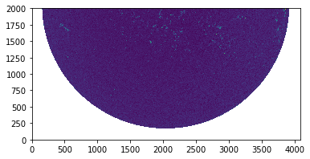

```python
import matplotlib.pyplot as plt
plt.imshow(smap.data[0:2000, :], origin='lower');
plt.show()
```

### 关于 Scaled Image Data

这一部分将更仔细地检查 Astropy 对示例中的 FITS 文件的处理.

参见 http://docs.astropy.org/en/stable/io/fits/usage/image.html#scaled-data

> Images are scaled only when either of the BSCALE/BZERO keywords are present in the header and either of their values is not the default value (BSCALE=1, BZERO=0).

由于 `astropy.io.fits` 的特性, 读取 'Scaled Image Data' 时, 调用 `.data` 将自动对数据进行缩放:

```
physical value = BSCALE * (storage value) + BZERO
```

`astropy.io.fits.open` 中使用 `do_not_scale_image_data=True` 可禁用这一步骤.

见 [astropy.io.fits FAQ](http://docs.astropy.org/en/stable/io/fits/appendix/faq.html#why-is-an-image-containing-integer-data-being-converted-unexpectedly-to-floats)

数据类型:

| BITPIX | Numpy Data Type |
| --- | --- |
| 8 | numpy.uint8 (unsigned integer) |
| 16 | numpy.int16 |
| 32 | numpy.int32 |
| -32 | numpy.float32 |
| -64 | numpy.float64 |

可以使用 Astropy 的命令行工具在 shell 中查看信息:

```python
fname = 'data/hmi.B_720s.20150827_052400_TAI.field.fits'
!fitsinfo {fname}
```

```
Filename: data/hmi.B_720s.20150827_052400_TAI.field.fits
No.    Name      Ver    Type      Cards   Dimensions   Format
  0  PRIMARY       1 PrimaryHDU       6   ()
  1                1 CompImageHDU    155   (4096, 4096)   int32
```

可以看到该文件存储的数据类型是整形.

用命令行工具查看关键字 'BITPIX':

```python
!fitsheader -e 1 --keyword BITPIX {fname}
```

```
# HDU 1 in data/hmi.B_720s.20150827_052400_TAI.field.fits:
BITPIX  =                   32 / data type of original image
```

使用 `astropy.io.fits`:

```python
from astropy.io import fits
hdulist = fits.open(fname)
hdu = hdulist[1]
```

```python
hdu.header['BITPIX']
```

```
32
```

```python
hdu.header['BSCALE']
```

```
0.01
```

```python
hdu.header['BZERO']
```

```
0.0
```

```python
hdulist.verify('silentfix+warn')  # 调用 `.data` 时如果出错, 需要先进行这一步修复
```

```python
hdu.data.dtype  # 已自动变换为 'physical value', 同时 `.header` 将被修改
```

```
dtype('float64')
```

```python
hdu.data[1000, 1000]
```

```
142.83
```

```python
hdu.data[0,0]  # -2147483648 被转为 nan
```

```
nan
```

```python
hdu.header['BITPIX']  # 值被改变了. 同时 'BSCALE', 'BZERO' 被删除
```

```
-64
```

手动 scale:

'BSCALE' 虽然之前已被删除, 但值仍存储在 `._orig_bscale` 中. `.scale` 将使用这个值.

```python
hdu.scale('int32')  # 在此之后 `.data` 将变换回 'storage value'
```

```python
hdu._orig_bscale
```

```
0.01
```

```python
hdu._orig_bzero
```

```
0
```

```python
hdu.data[1000, 1000]
```

```
14283
```

```python
hdu.data[0, 0]  # nan 被转为 -2147483648
```

```
-2147483648
```

```python
hdu.header['BITPIX']  # 值再次被改变了
```

```
32
```

使用 SunPy 处理时, 'BITPIX', 'BSCALE', 'BZERO' 的值被保留, `.data` 仍进行了 scale 的过程.

针对不同文件, 如果 SunPy 的程序内部使用 `astropy.io.fits` 处理文件时调用了 `.data` 再返回 header, 即 `astropy.io.fits` 已经如上所述改变了 header, 那么 SunPy 所返回的 header 中 'BITPIX', 'BSCALE', 'BZERO' 可能已经被改变.

下面的例子中得到的 header 是最初的值:

```python
import sunpy.map
smap = sunpy.map.Map('data/hmi.B_720s.20150827_052400_TAI.field.fits')
```

```python
smap.meta['BITPIX']  # 得到的是未被改变的 header
```

```
32
```

```python
smap.meta['BSCALE']
```

```
0.01
```

```python
smap.meta['BZERO']
```

```
0.0
```

```python
smap.data[1000, 1000]  # 这一步并不改变 `.meta` 的值
```

```
142.83
```

```python
smap.meta['BITPIX']  # 不变
```

```
32
```

```python
smap.meta['BSCALE']  # 不变
```

```
0.01
```

```python
smap.meta['BZERO']  # 不变
```

```
0.0
```

### 坐标和单位

**SunPy map** http://docs.sunpy.org/en/stable/code_ref/map.html#using-map-objects

> A number of the **properties** of this class are returned as **two-value named tuples** that can either be
> - indexed by position: **[0], [1]**
> - be accessed by the names:
>   - pixel axes: **.x, .y**  
>     x and y refer to the FITS axes (x for columns y for rows)
>   - spatial axes: **.axis1, .axis2**  
>     axis1 corresponds to the coordinate axis for x and axis2 corresponds to y.

```python
smap.dimensions
```

```
PixelPair(x=<Quantity 4096. pix>, y=<Quantity 4096. pix>)
```

```python
smap.dimensions.x  # 得到一个 `astropy.units.quantity.Quantity`, 包含 value 和 unit
```

$4096 \; \mathrm{pix}$

```python
smap.dimensions.x.unit
```

$\mathrm{pix}$

```python
smap.dimensions.x.value
```

```
4096.0
```

`astropy.units` 的使用方法:

```python
import astropy.units as u
```

```python
u.AA
```

$\mathrm{\mathring{A}}$

```python
4096 * u.pix  # same as `u.pixel`
```

$4096 \; \mathrm{pix}$

```python
(4096, 4096) * u.pix  # 注意这里是 `astropy.units` 的运算, 和 list 运算规则不同
```

$[4096,~4096] \; \mathrm{pix}$

```python
smap.dimensions.x.unit is u.pix  # 说明 x 是单位是 u.pix
```

```
True
```

```python
type(smap.center)
```

```
astropy.coordinates.sky_coordinate.SkyCoord
```

```python
list((0, 0) * u.pix)
```

```
[<Quantity 0. pix>, <Quantity 0. pix>]
```

```python
smap.pixel_to_world(*(4096, 4096) * u.pix)
```

```
<SkyCoord (Helioprojective: obstime=2015-08-27 05:22:21.800000, rsun=696000000.0 m, observer=<HeliographicStonyhurst Coordinate (obstime=2015-08-27 05:22:21.800000): (lon, lat, radius) in (deg, deg, m)
    (0., 7.089004, 1.51196988e+11)>): (Tx, Ty) in arcsec
    (-1040.36199634, -1030.86554911)>
```

查看 `SkyCoord` 的帮助:

```python
import astropy.coordinates
help(astropy.coordinates.sky_coordinate.SkyCoord)
```

```python
smap.center.Tx
```

$-7.65399\mathrm{{}^{\prime\prime}}$

```python
smap.pixel_to_world(*(2000, 2000) * u.pix)
```

```
<SkyCoord (Helioprojective: obstime=2015-08-27 05:22:21.800000, rsun=696000000.0 m, observer=<HeliographicStonyhurst Coordinate (obstime=2015-08-27 05:22:21.800000): (lon, lat, radius) in (deg, deg, m)
    (0., 7.089004, 1.51196988e+11)>): (Tx, Ty) in arcsec
    (16.55031204, 26.53575639)>
```

```python
smap.pixel_to_world(*(2000, 2000) * u.pix).transform_to('heliographic_stonyhurst')
```

```
<SkyCoord (HeliographicStonyhurst: obstime=2015-08-27 05:22:21.800000): (lon, lat, radius) in (deg, deg, km)
    (1.00568591, 8.68202918, 696000.0000022)>
```

查看坐标信息:

```python
smap.coordinate_frame
```

```
/home/lydia/miniconda3/lib/python3.6/site-packages/sunpy/map/mapbase.py:669: Warning: Missing metadata for heliographic longitude: assuming longitude of 0 degrees
  lon=self.heliographic_longitude,
```

```
<Helioprojective Frame (obstime=2015-08-27 05:22:21.800000, rsun=696000000.0 m, observer=<HeliographicStonyhurst Coordinate (obstime=2015-08-27 05:22:21.800000): (lon, lat, radius) in (deg, deg, m)
    (0., 7.089004, 1.51196988e+11)>)>
```

出现这个 Warning 时:

```python
smap.meta['hgln_obs'] = 0.; smap.meta['hgln_obs'] = 0.; smap.meta['hgln_obs'] = 0.
smap.coordinate_frame
```

```
<Helioprojective Frame (obstime=2015-08-27 05:22:21.800000, rsun=696000000.0 m, observer=<HeliographicStonyhurst Coordinate (obstime=2015-08-27 05:22:21.800000): (lon, lat, radius) in (deg, deg, m)
    (0., 7.089004, 1.51196988e+11)>)>
```

### 语法对比

比较 `plothmi.py` 与对应 IDL 程序的语法:

下面的语句中, 为了简便和方便对比, 使用了自定义的一些函数. 导入方法:

```
from usr_sunpy import read_sdo, plot_map, plot_vmap, image_to_helio
```

读取数据

```
; IDL
read_sdo,<fname>,index,data
index2map,index,data,mapa
```

```
# Python
# 为简化过程而自定义的函数, 读入时打印文件名和数组大小
mapa = read_sdo(<fname>)
```

旋转

```
; IDL
; 2 表示180°
mapbx.data = rotate(mapbx,2)
mapby.data = rotate(mapbx,2)
mapbz.data = rotate(mapbx,2)
```

```
# Python
# 利用 'crota2' 的值确定角度
mapbx = mapbx.rotate(order=1)
mapby = mapby.rotate(order=1)
mapbz = mapbz.rotate(order=1)
```

截取

```
; IDL
sub_map,mapbx,smapbx,xrange=[500,800.0],yrange=[-500,-100.0]
sub_map,mapby,smapby,ref_map=smapbx
sub_map,mapbz,smapbz,ref_map=smapbx
```

```
# Python
# 左下到右上
bl = SkyCoord(500*u.arcsec, -500*u.arcsec, frame=mapbz.coordinate_frame)
tr = SkyCoord(800*u.arcsec, -100.*u.arcsec, frame=mapbz.coordinate_frame)
smapbx = mapbx.submap(bl, tr)
smapby = mapby.submap(bl, tr)
smapbz = mapbz.submap(bl, tr)
```

绘图

```
; IDL
plot_map,smapbz,dmax=2000,dmin=-2000,color=0,charsize=1.8,...
plot_vmap,/over,smapbx,smapby,mapbz=smapbz,limit=180,scale=0.012,iskip=15,jskip=15,...
```

```
# Python
# 主要调用的是 matplotlib
fig = plt.figure()
ax = fig.add_subplot(111, projection=smapbz) # 使用 smapbz 中定义的坐标系统
plot_map(ax, smapbz)
plot_vmap(ax, smapbx, smapby, smapbz, iskip=iskip, jskip=jskip, cmin=100., vmax=500., cmap='binary', ...)
```

坐标变换

```
; IDL
; magnetic_modeling_codes/.../05projection_modified_version.pro
```

```
# Python
# `image_to_helio`(变换为 Helioprojective(Cartesian) system)
# 调用自定义的旋转矩阵函数 `proj_matrix`, 参考文献与原IDL程序相同
hx, hy = image_to_helio(smapbz)  # numpy 数组
smapbx_h, smapby_h, smapbz_h = image_to_helio(smapbx, smapby, smapbz) # sunpy `Map`

plot_map(ax, smapbz_h, coords=(hx, hy))
plot_vmap(ax, smapbx_h, smapby_h, smapbz_h, coords=(hx, hy), ...)
```

## 插值, 拟合

选择不限于这里列举的包, 以后也可能会有更合适的方法出现.

相关安装见 安装和配置

### 插值

- numpy

  ```
  f = interp1d(x, y, kind='cubic'[, fill_value='extrapolate'])
  x2 = np.linspace(...)
  y2 = f(x2)
  ```

  见 examples/test_plot.py
- scipy https://docs.scipy.org/doc/scipy/tutorial/interpolate.html

### 求极值

- PeakUtils http://peakutils.readthedocs.io/en/latest/

官方例图 (http://peakutils.readthedocs.io/en/latest/tutorial_a.html):

```
import peakutils
indexes = peakutils.indexes(y, thres=0.5, min_dist=30)
```

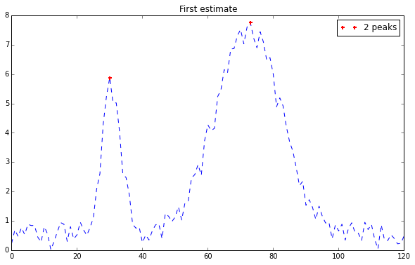

Enhancing the resolution by interpolation:

```
peaks_x = peakutils.interpolate(x, y, ind=indexes)
```

### 拟合

- LMFIT (Non-Linear Least-Squares Minimization and Curve-Fitting)

下载 https://github.com/lmfit/lmfit-py

文档 http://lmfit.github.io/lmfit-py/

有现成模型, 也可以自定义模型.  
可以方便地叠加不同拟合模型(比如多个高斯, 线性加高斯, 等等).  
例子见 examples/lmfits (来自 [LMFIT网站示例](http://lmfit.github.io/lmfit-py/builtin_models.html#example-1-fit-peak-data-to-gaussian-lorentzian-and-voigt-profiles) )

使用内置模型:

```
from lmfit.models import GaussianModel  # 内置的模型

data = np.loadtxt('test_peak.dat')
x = data[:, 0]
y = data[:, 1]

mod = GaussianModel()  # 实例化一个模型
pars = mod.guess(y, x=x)  # 给初值
out = mod.fit(y, pars, x=x)  # 拟合结果

print(out.fit_report())  # 拟合结果的详细信息
plt.plot(x, out.init_fit, 'k--')
plt.plot(x, out.best_fit, 'r-')
```

```
[[Model]]
    Model(voigt)
[[Fit Statistics]]
    # fitting method   = leastsq
    # function evals   = 21
    # data points      = 401
    # variables        = 4
    chi-square         = 10.9301767
    reduced chi-square = 0.02753193
    Akaike info crit   = -1436.57602
    Bayesian info crit = -1420.60017
[[Variables]]
    sigma:      0.89518909 +/- 0.01415450 (1.58%) (init = 0.8775)
    center:     9.24374847 +/- 0.00441903 (0.05%) (init = 9.25)
    amplitude:  34.1914737 +/- 0.17946860 (0.52%) (init = 65.43358)
    gamma:      0.52540198 +/- 0.01857955 (3.54%) (init = 0.7)
    fwhm:       3.22385343 +/- 0.05097475 (1.58%) == '3.6013100*sigma'
    height:     10.0872204 +/- 0.03482130 (0.35%) == 'amplitude*wofz((1j*gamma)/(sigma*sqrt(2))).real/(sigma*sqrt(2*pi))'
[[Correlations]] (unreported correlations are < 0.100)
    C(sigma, gamma)     = -0.928
    C(amplitude, gamma) =  0.821
    C(sigma, amplitude) = -0.651
```

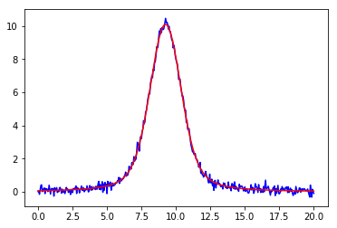

```python
%matplotlib inline
%run examples/lmfits/fit_peak.py
```

多个模型叠加:

```
from lmfit.models import ExponentialModel, GaussianModel

data = np.loadtxt('NIST_Gauss2.dat')
x = data[:, 0]
y = data[:, 1]

exp_mod = ExponentialModel(prefix='exp_')
gauss1 = GaussianModel(prefix='g1_')
gauss2 = GaussianModel(prefix='g2_')

pars1 = exp_mod.guess(y, x=x)  # 分段设参数的方法见下面的脚本文件
pars2 = gauss1.guess(y, x=x)
pars3 = gauss2.guess(y, x=x)

pars = pars1 + pars2 + pars3  # 叠加参数
mod = gauss1 + gauss2 + exp_mod  # 叠加模型

out = mod.fit(y, pars, x=x)

print(out.fit_report())
plt.plot(x, y, 'b')
plt.plot(x, out.init_fit, 'k--')
plt.plot(x, out.best_fit, 'r-')
```

```python
%%capture output
%matplotlib inline
%run examples/lmfits/fit_peaks.py
```

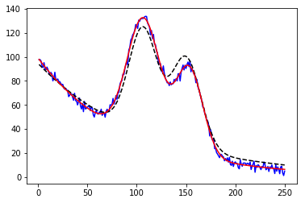

```python
output.outputs[0]
```

```python
%%capture output
%matplotlib inline
%run examples/lmfits/fit_peaks_components.py
```

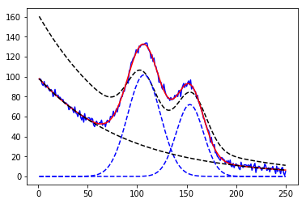

```python
output.outputs[0]
```

自定义模型的方法见 [LMFIT网站示例](http://lmfit.github.io/lmfit-py/builtin_models.html#user-defined-models)

### 其他

- Sherpa(Modeling and Fitting) http://cxc.cfa.harvard.edu/contrib/sherpa/
- 2-D Fitting in Sherpa https://python4astronomers.github.io/fitting/image.html
- *etc.*

## copy 注意事项

**"shallow copy"** vs **"deep copy"**

- 对于 list 的情况

演示插件 https://github.com/lgpage/nbtutor

```python
%%nbtutor -r -f -i
from copy import deepcopy
a = [1, 2, 3]
b = a
c = deepcopy(a)
d = a[:] # 列表的切片是深拷贝
b[0] = -1
c[1] = -2
d[2] = -3
```

```python
print(id(a), id(b), id(c), id(d))
```

```
23284866388232 23284866388232 23284855519880 23284856061064
```

[网页版演示](http://t.cn/RgK1OHf)

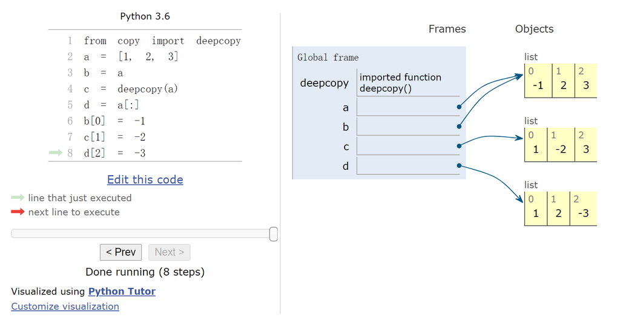

- 对于 dict 的情况

```python
%%nbtutor -r -f -i
from copy import deepcopy
a = {1:1, 2:2, 3:3}
b = a
c = a.copy()  # 深拷贝
d = deepcopy(a)
b[1] = -1
c[2] = -2
d[3] = -3
```

```python
print(id(a), id(b), id(c), id(d))
```

```
22492371132064 22492371132064 22492397510376 22492397507280
```

[网页版演示](http://t.cn/RgKrHOx)

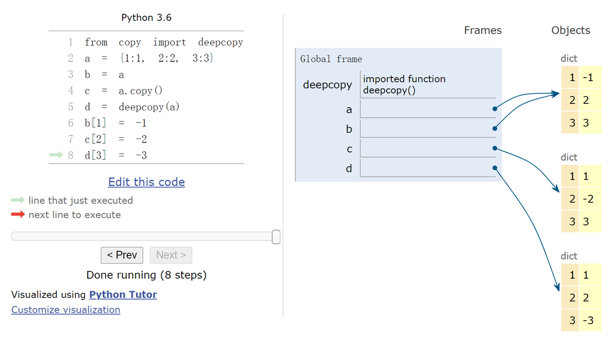

- 对于 set 的情况

```python
%%nbtutor -r -f -i
from copy import deepcopy
a = {1, 2, 3}
b = a
c = a.copy()  # 深拷贝
d = deepcopy(a)
b.add(4)
c.add(5)
d.add(6)
```

```python
print(id(a), id(b), id(c), id(d))
```

```
22492476895528 22492476895528 22492476895304 22492374233384
```

[网页版演示](http://t.cn/RgKd3E7)

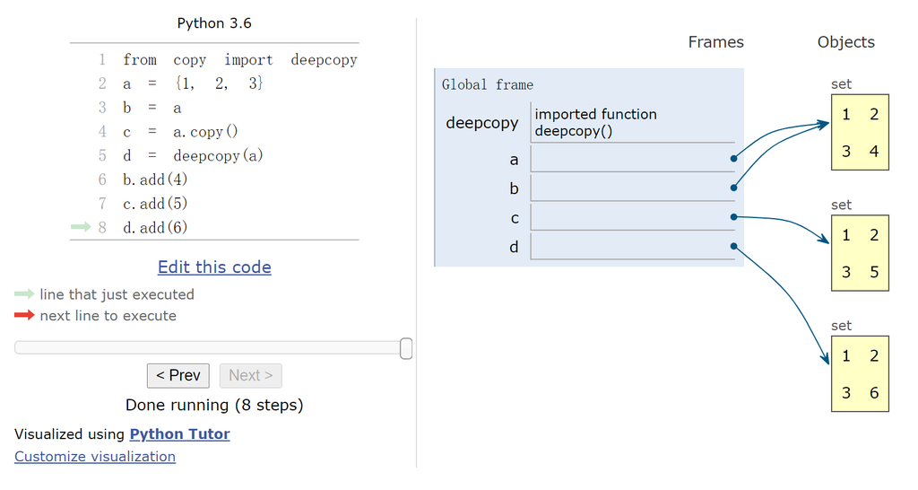

- 对于 numpy 的情况

```python
%%nbtutor -r -f -i
import numpy as np
a = np.arange(1, 4)
b = a[:] # 浅拷贝!
c = a.copy()  # 深拷贝, 同 deepcopy(a)
d = a[[0, 2]]  # 花式切片是深拷贝
b[0] = -1
c[1] = -2
d[1] = -3
```

```python
# id 虽各不同, 但 .__array_interface__['data'][0] 可能相同
for i in (a, b, c, d):
    print(id(i), i.__array_interface__['data'][0])
```

```
22928831926400 93879086511872
22928831928960 93879086511872
22928829201984 93879072448320
22928829199344 93879078700736
```

[网页版演示](http://t.cn/Rg9hST6) (**Site Error**: Ruby and Python+Anaconda backends are permanently unavailable)

参见之前的 np.matrix, np.asmatrix

## 其他格式文件读写

### 用 pandas 读 csv

```python
import pandas as pd
data = pd.read_csv("data/data.csv")
data
```

|  | col1 | col2 | col3 |
| --- | --- | --- | --- |
| 0 | row1 | 1 | 10.0 |
| 1 | row2 | 2 | 0.2 |
| 2 | row3 | 3 | 300.0 |

```python
data.columns
```

```
Index(['col1', 'col2', 'col3'], dtype='object')
```

```python
data.col1
```

```
0    row1
1    row2
2    row3
Name: col1, dtype: object
```

```python
data['col1']
```

```
0    row1
1    row2
2    row3
Name: col1, dtype: object
```

只取一部分:

```python
data = pd.read_csv("data/data.csv", nrows=2, usecols=(0,2))
data
```

|  | col1 | col3 |
| --- | --- | --- |
| 0 | row1 | 10.0 |
| 1 | row2 | 0.2 |

对于超大文件, 参见: https://www.dataquest.io/blog/pandas-big-data/

### Fortran 二进制文件读写

#### Unformatted (sequential)

使用 `scipy.io.FortranFile`  
参考: https://docs.scipy.org/doc/scipy-0.15.1/reference/generated/scipy.io.FortranFile.read_record.html

```python
# python (write)
from scipy.io import FortranFile
var1 = 1.1  # '<f8'
var2 = 0  # '<i8'
arr = np.arange(6.).reshape((2, 3))  # '(2, 3)<f8'
print(var1, var2)
print(arr)
print(f'arr[0, 1] = {arr[0, 1]}')

# 多行存入
with FortranFile('data/data_fortran1-1.dat', 'w') as f:
    f.write_record(var1)
    f.write_record(var2)
    f.write_record(arr)
# 单行存入
with FortranFile('data/data_fortran1-2.dat', 'w') as f:
    f.write_record(var1, var2, arr)
```

```
1.1 0
[[0. 1. 2.]
 [3. 4. 5.]]
arr[0, 1] = 1.0
```

```python
# python (read)
from scipy.io import FortranFile
# 多行存入的情况
with FortranFile('data/data_fortran1-1.dat', 'r') as f:
    var1 = float(f.read_record('<f8'))
    var2 = int(f.read_record('<i8'))  # 注意精度(上面python存入的是默认'int64')
    arr = f.read_record('(2, 3)<f8')
print('data_fortran1-1.dat')
print(var1, var2)
print(arr)
# 单行存入的情况
with FortranFile('data/data_fortran1-2.dat', 'r') as f:
#     data = f.read_record('<f8, <i8, (2, 3)<f8')  # 不指定名称
    data = f.read_record([('var1', '<f8'), ('var2', '<i8'),
                         ('arr', '(2, 3)<f8')])  # 指定名称: (name, dtype)
print('\ndata_fortran1-2.dat')
print(f'keys = {data.dtype.names}')  # 如读取时未指定名称则为 ['f0', 'f1', ...]
print(float(data['var1']), int(data['var2']))
print(data['arr'])
```

```
data_fortran1-1.dat
1.1 0
[[0. 1. 2.]
 [3. 4. 5.]]

data_fortran1-2.dat
keys = ('var1', 'var2', 'arr')
1.1 0
[[[0. 1. 2.]
  [3. 4. 5.]]]
```

```python
%%bash
cd examples/
ifort -o test_read_seq test_read_seq.f90
./test_read_seq
```

```
 data_fortran1-1.dat
   1.1  0.0
   0.0  1.0  2.0
   3.0  4.0  5.0
 arr(2, 1) =   1.0

 data_fortran1-2.dat
   1.1  0.0
   0.0  1.0  2.0
   3.0  4.0  5.0
 arr(2, 1) =   1.0
```

见 Structured arrays: https://docs.scipy.org/doc/numpy/user/basics.rec.html

#### Unformatted (stream)

`struct` 参考 https://docs.python.org/3/library/struct.html

```python
# python (write)
import struct
var1 = 1.1  # '<f8'
var2 = 0  # '<i8'
arr = np.arange(6.).reshape((2, 3))  # '(2, 3)<f8'
print(var1, var2)
print(arr)
print(f'arr[0, 1] = {arr[0, 1]}')
with open('data/data_fortran2.dat', 'wb') as f:
    f.write(struct.pack('d', var1))
    f.write(struct.pack('i', var2))  # 注意 `struct` 的 'i' 是 '<i4'
    arr.tofile(f)
```

```
1.1 0
[[0. 1. 2.]
 [3. 4. 5.]]
arr[0, 1] = 1.0
```

```python
# python (read)
# 使用 `np.fromfile`, 读入的是 `ndarray`
with open('data/data_fortran2.dat', 'rb') as f:
    var1 = float(np.fromfile(f, dtype='<f8', count=1))
    var2 = int(np.fromfile(f, dtype='<i4', count=1))
    arr = np.fromfile(f, dtype='<f8').reshape(2, 3)
print(var1, var2)
print(arr)
```

```
1.1 0
[[0. 1. 2.]
 [3. 4. 5.]]
```

```python
%%bash
cd examples/
ifort -o test_read_stream test_read_stream.f90
./test_read_stream
```

```
  1.1 0.0
  0.0 1.0 2.0
  3.0 4.0 5.0
 arr(2, 1) =  1.0
```

### HDF5 文件读写, NCDF, CDF 文件读取

#### 读写 HDF5 文件, 读 NCDF 文件

HDF5 格式介绍 https://portal.hdfgroup.org/display/HDF5/Introduction+to+HDF5

相关包: `h5py` 或 `pandas` + `pytables` (http://www.pytables.org/usersguide/datatypes.html)

安装见 安装和配置

- 查看

```
$ h5dump -H <filename>.hdf5
$ ncdump -h <filename>.ncdf
```

- 用 `h5py` 读写:

```
import h5py
arr = np.arange(10000).reshape(50,-1)
with h5py.File('test.hdf5', 'w') as f:
    f['data'] = arr
    # 或
    # f.create_dataset('data', data=arr)
    # 其中 compression='gzip', compression_opts=[0-9], 可分条目用不同压缩
    f['lb'] = list(range(100))
```

读纯 HDF5/NCDF 文件:

```
f = h5py.File('test.hdf5', 'r')
keys = list(f.keys())  # ['data', 'lb']
items = list(f.items())
a = f['data'].value
```

读 pandas 存的文件:

```
a = f['data']['block0_values'].value
f.close()
# f['<key>'] 得到的是 Dataset 或 Group 的引用
# 用 f['<key>'].value 或切片 f['<key>'][:] 得到原来的格式
# f['<key>'] 可替代为f.get('<key>')
# 关闭之后 f['data'] 的引用失效, 因此存出数据要加上.value或[:]保存数据, 或使用 deepcopy
```

打印读取的信息:

```
from pprint import pprint
pprint([(f'{k:>20}', f'{str(f[k].shape):>20}', f'{str(f[k].dtype):>20}') for k in f.keys()])
pprint([(f'{k:>20}', f"{str(f[k]['block0_values'].shape):>20}", f"{str(f[k]['block0_values'].dtype):>20}") for k in f.keys()])
```

- 用pandas读写:

```
import pandas as pd
```

写:

```
arr2 = pd.DataFrame(arr)
# complevel=[0-9], complib={'zlib', 'lzo', 'bzip2', 'blosc'}
with pd.HDFStore('test2.hdf5', 'w') as f:
    f['data'] = arr2
    f['lb'] = pd.DataFrame(list(range(100)))
```

读 pandas 写的文件:

```
f = pd.HDFStore('test2.hdf5', 'r')
keys = f.keys()  # ['/data', '/lb'], 存在子目录
items = list(f.items())
a = f.data.values  # a = f.<key> 得到的是 DataFrame 的引用, f.<key>.values 得到原来的格式
f.close()
```

- 读纯 HDF5/NCDF 文件:  
  比如 h5py 写的文件, 目录结构和 pandas 写的不同, 要用`.root`  
  其他软件生成的文件可能不能读

```
f = pd.HDFStore('test.hdf5', 'r')
keys = list(f.root._v_children.keys())  # ['data', 'lb']
items = list(f.root._v_children.items())  # ['data', 'lb'], 有些文件没有.items
a = f.root.data.read()
# f.root 得到 tables.group.RootGroup, f.root.<key> 得到tables.group.CArray
# f.get_node('<key>') 得到 tables.group.CArray
# f.root.<key> 可替代为 f['<key>'] (有些文件不行)
f.close()
```

打印 (以免数据有 None, 用 `np.shape`):

```
pprint([(f'{k}'                      .rjust(20),
         f'{np.shape(f.get_node(k))}'.rjust(20),
         f'{np.dtype(f.get_node(k))}'.rjust(20))
         for k in list(f.root._v_children.keys())])
```

Bug: 无法读出 `H5T_STRING`

#### 大小比较

用于比较的文件名说明:

| Filename | Method |
| --- | --- |
| *xxx*_np.npy | **`np.save`** |
| *xxx*_np.npz | **`np.savez_compressed`** |
| *xxx*_compimg.fits | **FITS** CompImageHDU (compressed) |
| *xxx*_prim.fits | **FITS** PrimaryHDU |
| *xxx*_h5py_0.hdf5 | **`h5py`** no compression |
| *xxx*_h5py_gzip.hdf5 | **`h5py`** compression='gzip', compression_opts=9 |
| *xxx*_h5py_lzf.hdf5 | **`h5py`** compression='lzf' |
| *xxx*_pd_0.hdf5 | **`pandas`** no compression |
| *xxx*_pd_blosc.hdf5 | **`pandas`** complib='blosc', complevel=9 |
| *xxx*_pd_bzip2.hdf5 | **`pandas`** complib='bzip2', complevel=9 |
| *xxx*_pd_lzo.hdf5 | **`pandas`** complib='lzo', complevel=9 |
| *xxx*_pd_zlib.hdf5 | **`pandas`** complib='zlib', complevel=9 |

- 对于相关性强的数组

```python
%run examples/test_hdf5.py
print()
!du -h data/test_*.np*
print()
!du -h data/test_h5py_*.hdf5
print()
!du -h data/test_pd_*.hdf5
```

```
array: 15.3 M

7.7M	data/test_np.npy
1.3M	data/test_np.npz

16M	data/test_h5py_0.hdf5
2.9M	data/test_h5py_gzip.hdf5
7.7M	data/test_h5py_lzf.hdf5

16M	data/test_pd_0.hdf5
272K	data/test_pd_blosc.hdf5
248K	data/test_pd_bzip2.hdf5
256K	data/test_pd_lzo.hdf5
172K	data/test_pd_zlib.hdf5
```

- 随机数数组

```python
%run examples/test_hdf5_2.py
print()
!du -h data/test_*.np*
print()
!du -h data/test_h5py_*.hdf5
print()
!du -h data/test_pd_*.hdf5
```

```
array: 15.3 M

7.7M	data/test_np.npy
7.2M	data/test_np.npz

16M	data/test_h5py_0.hdf5
8.0M	data/test_h5py_gzip.hdf5
9.5M	data/test_h5py_lzf.hdf5

16M	data/test_pd_0.hdf5
7.7M	data/test_pd_blosc.hdf5
7.2M	data/test_pd_bzip2.hdf5
7.7M	data/test_pd_lzo.hdf5
7.1M	data/test_pd_zlib.hdf5
```

- 从 FITS 文件读取再转存

```python
fname = 'data/hmi.B_720s.20150827_052400_TAI.field.fits'
%run examples/test_fits_hdf5.py {fname}
print()
!du -h {fname}
print()
!du -h data/fits_*.np*
print()
!du -h data/fits_*.fits
print()
!du -h data/fits_h5py_*.hdf5
print()
!du -h data/fits_pd_*.hdf5
```

```
array: 64.0 M

21M	data/hmi.B_720s.20150827_052400_TAI.field.fits

65M	data/fits_np.npy
27M	data/fits_np.npz

21M	data/fits_compimg.fits
65M	data/fits_prim.fits

65M	data/fits_h5py_0.hdf5
27M	data/fits_h5py_gzip.hdf5
40M	data/fits_h5py_lzf.hdf5

65M	data/fits_pd_0.hdf5
23M	data/fits_pd_blosc.hdf5
21M	data/fits_pd_bzip2.hdf5
23M	data/fits_pd_lzo.hdf5
20M	data/fits_pd_zlib.hdf5
```

```python
fname = 'data/hmi.B_720s.20150827_052400_TAI.disambig.fits'
%run examples/test_fits_hdf5.py {fname}
print()
!du -h {fname}
print()
!du -h data/fits_*.np*
print()
!du -h data/fits_*.fits
print()
!du -h data/fits_h5py_*.hdf5
print()
!du -h data/fits_pd_*.hdf5
```

```
array: 32.0 M

5.4M	data/hmi.B_720s.20150827_052400_TAI.disambig.fits

33M	data/fits_np.npy
5.2M	data/fits_np.npz

5.4M	data/fits_compimg.fits
33M	data/fits_prim.fits

33M	data/fits_h5py_0.hdf5
5.3M	data/fits_h5py_gzip.hdf5
9.7M	data/fits_h5py_lzf.hdf5

33M	data/fits_pd_0.hdf5
9.5M	data/fits_pd_blosc.hdf5
4.1M	data/fits_pd_bzip2.hdf5
7.6M	data/fits_pd_lzo.hdf5
4.8M	data/fits_pd_zlib.hdf5
```

#### 读取 CDF 文件

相关包 `cdflib`, 安装见 安装和配置#其他

```
import cdflib
f = cdflib.CDF("<filename>.cdf")
f.cdf_info()  # 总体信息
f.varinq('<key>')  # 变量信息
f.varget('<key>')  # 值
f.close()
```

### NumPy to VTK

参考 https://pyscience.wordpress.com/2014/09/06/numpy-to-vtk-converting-your-numpy-arrays-to-vtk-arrays-and-files/  
以及 安装和配置  
e.g.  
运行 examples/field2dvtk.py ,  
打开Paraview, 选择 state 文件 'field2d.pvsm', 再选择数据文件 'field2d.vtr'

### Matlab mat 文件读写

(未测试)

```
import scipy.io
scipy.io.loadmat("<filename>", mdict=None, appendmat=True, **kwargs)
# 如果 appendmat=True，则文件名不需要'.mat'后缀)
scipy.io.savemat("<filename>", mdict, appendmat=True, format='5',
                 long_field_names=False, do_compression=False, oned_as='row')
```

## 脚本相关

### 脚本结构

文件头:

```
#!/usr/bin/env python
# -*- coding: utf-8 -*-
```

脚本结构:

```
#!/usr/bin/env python
# -*- coding: utf-8 -*-
"""
假设这个文件的名称为 mymodule.py
使用 `imort mymodule` 导入
这些文字会出现在 `help(mymodule)` 或 `pydoc mymodule` 中
"""
c = 1
def func1(x, y, *args, **kwargs):
    """
    这个注释必须缩进
    args: a tuple - (arg1, arg2, ...)
    kwargs: a dict - {key1 : val1, key2 : val2}
    """
    global c
    return x + y + c
def func2(x):
    a = func1(x, x)
    return a
def _func3(x):  # `from xxx import *` 将不会导入这个函数
    pass
    return  # return 不写时返回 None
def main():
    # your code here
if __name__ == "__main__":
    main()
```

`import` 这个文档时, `__name__` 为模块名, 因此 `main()` 不执行

`help()` 也可以查看模块内的函数文档:

```python
import usr_sunpy
help(usr_sunpy.plot_map)
```

### try ... except ... 语法

```
try:
    ...
except ValueError as e:
    print('ValueError:', e)
except ZeroDivisionError as e:
    print('ZeroDivisionError:', e)
else:
    print('no error!')
finally:
    print('finally...')
```

见 Paraview 的例子

### Paraview 脚本

官方文档 https://www.paraview.org/ParaView/Doc/Nightly/www/py-doc/index.html

- 记录语句:
  1. Tools -> Start Trace
  2. 进行各种操作
  3. Tools -> Stop Trace 之后得到一个包含刚才操作命令的脚本, 参考其中的语句就可以写自己的脚本了.
- 需要导入的模块:

```
from paraview.simple import *
```

- 使用 pvpython (默认渲染) pvbatch (默认不渲染) 来执行脚本:

```
pvbatch myscript.py
```

也可以使用文件头 `#!/usr/bin/env pvbatch`, 加执行权限后直接执行:

```
./myscript.py
```

注意: 打包的 paraview 所使用的 python 是 paraview 自带的 python2.7

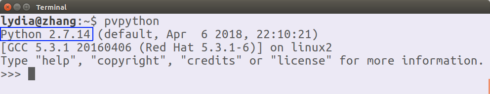

- 常用语句:

```
view = GetActiveView()
scene = GetAnimationScene()
```

`view.ViewTime` 修改时 `scene.AnimationTime` 不变 `scene.AnimationTime` 修改时 `view.ViewTime` 也同时被改变

注意: filter 必须是显示状态 (`Show(<filter>)`) 才能修改时间

```python
# e.g.
!code -n examples/stat1.py
```

- 字体选择参考路径:
  - /usr/share/fonts/truetype/dejavu/DejaVuSans.ttf
  - /home//miniconda3/lib/python3.6/site-packages/matplotlib/mpl-data/fonts/ttf/DejaVuSans.ttf
- python 调用问题 (paraview 5.5.0+ 没有这个问题):

paraview 某个版本之后就默认使用 python 2.7.11+.  
运行之前先修改环境变量 ( `PYTHONPATH` 和 `PYTHONSTARTUP`),  
运行结束结束后恢复这两个变量即可.  
这个过程可以使用脚本 (而不用alias):

```
#!/bin/bash
unset PYTHONSTARTUP  # 如果有的话
export PYTHONPATH=/<your_path>/ParaView/lib/python2.7/site-packages
/<your_path>/ParaView/bin/paraview $@
```

用这个脚本替代原有 `paraview`, `pvpython` 和 `pvbatch` 命令.

### Python 2 -> 3 的转换

比较推荐的安全的检查方式:

- 备份的原文件且自动生成转换过的文件

  ```
  $ 2to3 -w filename
  ```

- 手动比较, 在需要的地方对照修改 filename.bak  
  主要查看 print, range, map 等函数.  
  添加  
  `from __future__ import division, print_function`  
  在其他 import 前.

  ```
  $ sudo apt-get install meld
  $ meld filename filename.bak
  ```

- 确认无误后, 将手动修改的文件复制回去

  ```
  $ mv -v filename.bak filename
  ```

python 内查看版本的方法, 可用于 `if` 语句等 (更推荐用 `try...except...` 语法):

```python
import sys
print(sys.version_info >= (3, 0))
print(sys.version_info.major >= 3)
```

### 执行 shell 命令

https://docs.python.org/3/library/subprocess.html

```python
import subprocess

fname = 'installpy.ipynb'

# 默认是以列表形式传递参数
subprocess.run(["ls", "-l", fname]) # doesn't capture output

# 输出结果需要 `decode('ascii')` 转码
print(subprocess.run(["ls", "-l", fname], stdout=subprocess.PIPE)
                    .stdout.decode('ascii'))
print(subprocess.check_output(["ls", "-l", fname]).decode('ascii'))
```

```
-rw-rw-r-- 1 lydia lydia 142508 Jun 24 16:21 installpy.ipynb

-rw-rw-r-- 1 lydia lydia 142508 Jun 24 16:21 installpy.ipynb
```

利用 bash 的特长来做一些字符串操作:

```python
# 使用整行命令需要 `shell=True`, 虽然并不是推荐的做法, 但偶尔使用无妨 (见官方文档)
# `r`用来取消转义
# `echo`使用`-n`来去掉输出的 '\n'
fname_head = subprocess.check_output(r"echo -n %s | sed 's/\.ipynb//'"
                                     % fname, shell=True).decode('ascii')
# 或使用 strip 去掉 '\n'
fname_head = subprocess.check_output(r"echo %s | sed 's/\.ipynb//'"
             % fname, shell=True).strip().decode('ascii')
print(fname_head)
```

```
installpy
```

字符串编码见 [廖雪峰的网站](https://www.liaoxuefeng.com/wiki/0014316089557264a6b348958f449949df42a6d3a2e542c000/001431664106267f12e9bef7ee14cf6a8776a479bdec9b9000)

- 得到命令执行的路径

```python
import os
os.getcwd()
```

```
'/home/lydia/codes/zly/python/python-intro'
```

- 得到脚本文件所在的路径(仅脚本中使用)

```
os.path.split(os.path.abspath(__file__))[0]
```

或

```
os.path.dirname(os.path.abspath(__file__))
```

其中 `os.path.split` 和 `os.path.dirname` 的用法:

```python
os.path.split('your/path/filename')
```

```
('your/path', 'filename')
```

```python
os.path.dirname('your/path/filename')
```

```
'your/path'
```

`os.path.dirname` 类似于 bash 的 `dirname`

```python
!dirname 'your/path/filename'
```

```
your/path
```

### 脚本选项

推荐 `argparse`, 在过去的其他方法的基础上有所增强 https://docs.python.org/3/library/argparse.html

脚本内:

```
import argparse
parser = argparse.ArgumentParser(description='Process some integers.')
parser.add_argument('integers', metavar='N', type=int, nargs='+',
                    help='an integer for the accumulator')
parser.add_argument('--sum', dest='accumulate', action='store_const',
                    const=sum, default=max,
                    help='sum the integers (default: find the max)')
args = parser.parse_args()
print(args.accumulate(args.integers))
```

Shell:

```
$ python prog.py -h
usage: prog.py [-h] [--sum] N [N ...]
Process some integers.
positional arguments:
 N           an integer for the accumulator
optional arguments:
 -h, --help  show this help message and exit
 --sum       sum the integers (default: find the max)
```

### 处理 warnings

```
# Suppress warnings of NaNs:
with np.errstate(invalid='ignore'):
    ...
    ...
# Suppress other warnings, e.g.
import warnings
with warnings.catch_warnings():
    warnings.simplefilter("ignore")
    ...
    ...
# Or
warnings.simplefilter("ignore", category=xxx)  # UserWarning, FutureWarning, etc.
...
...
```

## urllib, requests

示例和文件来自 http://python4astronomers.github.io

注意 python3 不再使用 `urllib2`

```
# 方法1
import urllib
url = 'http://python4astronomers.github.io/_downloads/myidlfile.sav'
urllib.request.urlretrieve(url, 'myidlfile.sav')
# 方法2
with open('myidlfile.sav', 'wb') as f:
    f.write(urllib.request.urlopen(url).read())
# 方法3
import requests
with open('myidlfile.sav', 'wb') as f:
    f.write(requests.get(url).content)
# 分块下载
import requests
r = requests.get(<url>)
with open(filename, 'wb') as f:
    for chunk in r.iter_content(chunk_size=128):
        f.write(chunk)
```